# Part II - Ford GoBike Analysis for Feburary 2019

## by Judith Uba

## Distribution of Duration_sec

> Duration_sec is the main feature of interest as it showed how long each ride lasted. I plotted a histogram to see the distribution of this feature. From the plot, it is obvious that duration sec distribution is unimodal having a peak around 600 seconds

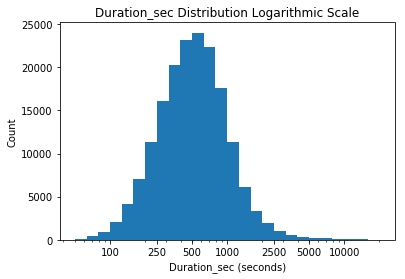

## Distribution of member_gender and user_type

> I looked at the relationship between the two categorical features, the member_gender snd the user_type to see how it was distributed. I plotted a multiple bar chart to visualize this information and get better insights. The member_gender includes Male, Female and Others while the user_type includes Customer and Subscribers.The Male riders have the highest population of the member_gender while the subscribers have the highest count when comapared to the customers. All the member_gender categories are either customers or subscribers

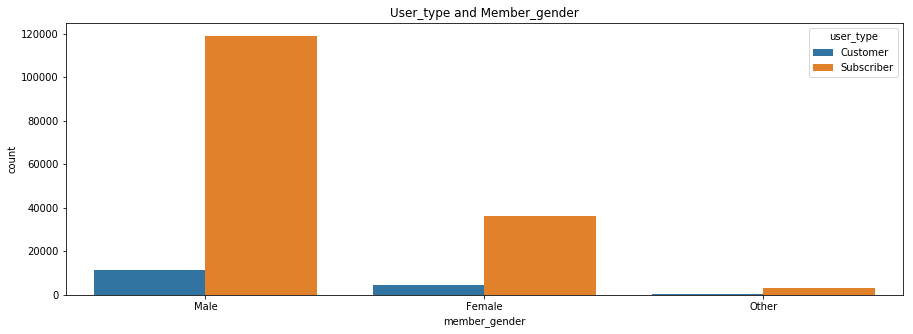

## Which day had the most rides?

> I looked at the date feature to get a clearer insight on how rides were distributed through out the month of feburary. I created a barchart and arranged it in descending order to show the days with the highest number of rides and lowest number of rides. On the 28th of feburary, 2019 the higest number of rides were taken, while on the 9th of feburary, 2019 the least number of rides were taken

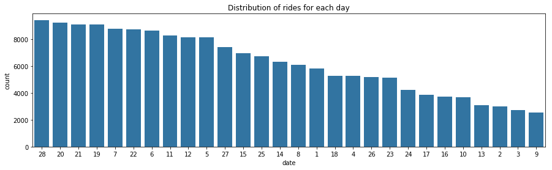

## Which category of member_gender and user_type took longer rides?

> To get a better understanding of the category of both member_gender and user_tyoe that took longer rides, I generated a piont plot for a multivariate exploration of the three features. From the point plot, I gathered that the female customers (female riders that are customers) took the longest rides while the male subscribers took the shortest rides

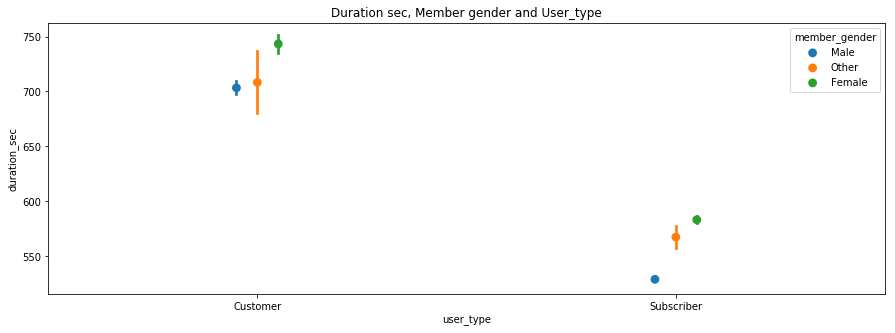

## Does sharing bike increase duration of rides?

> To know if bike sharing increased the duartion of rides and if all the user_type category shared bikes, I plotted the three features on a point plot. I found out that bike sharing was only exclusive to subscribers and subscribers that share bike took the shortest rides

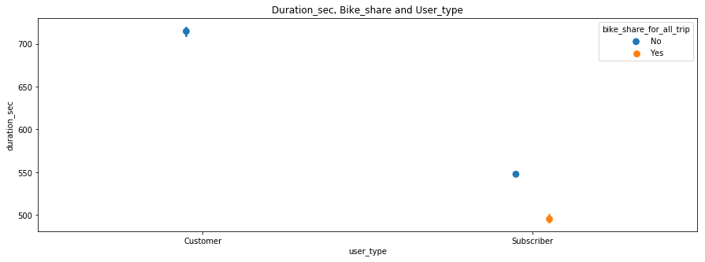